# Chapter 2 - Aesthetics

Introduction to Data Visualization with ggplot2

## All about aesthetics: color, shape and size

1. Map mpg onto the x aesthetic, and fcyl onto the y.
2. Swap the mappings of the first plot: fcyl onto the x aesthetic, and mpg onto the y.
3. Map wt onto x, mpg onto y, and fcyl onto color.
4. Modify the point layer of the previous plot by changing the shape argument to 1 and increasing the size to 4.

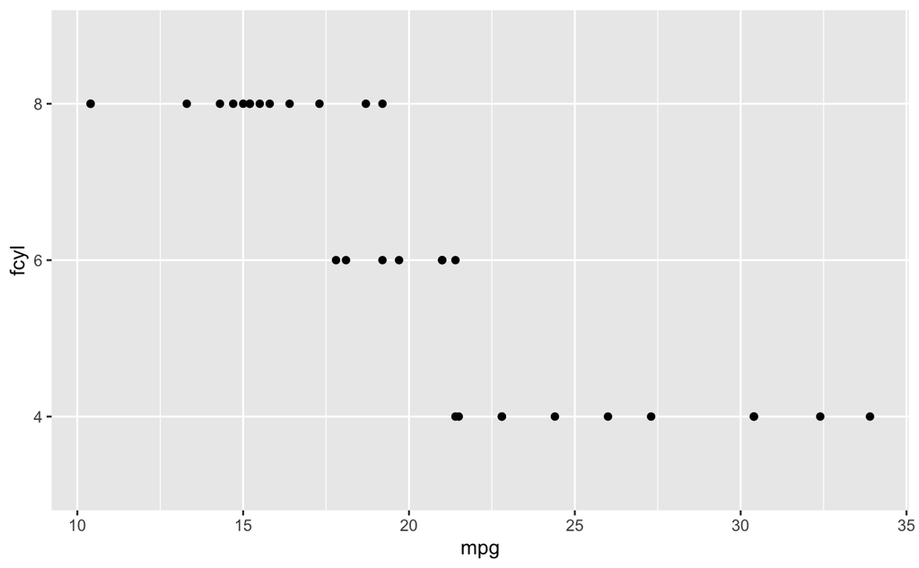

```r
library(ggplot2)
library(dplyr)
library(forcats)

# add 'fcyl' column as cyl column converted to a factor &
# a 'fam' column as am column converted to a factor
mtcars <- mutate(mtcars, fcyl = as_factor(cyl), fam = as_factor(am))
levels(mtcars$fam) <- c("automatic", "manual")

# Map x to mpg and y to fcyl
ggplot(mtcars, aes(x = mpg, y = fcyl)) +
  geom_point()
```

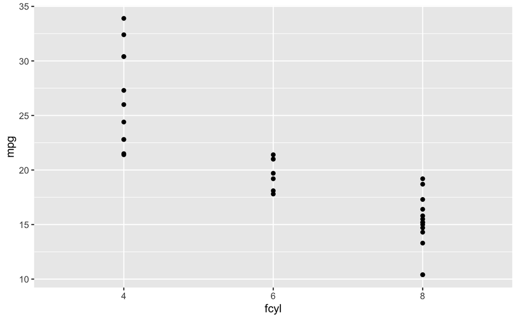

```r
# Swap mpg and fcyl
ggplot(mtcars, aes(x = fcyl, y = mpg)) +
  geom_point()
```

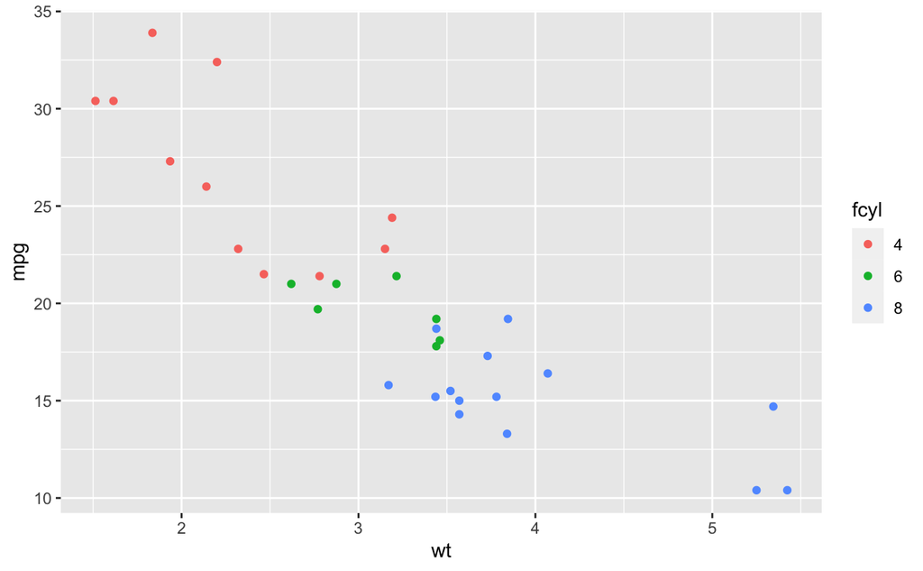

```r
# Map x to wt, y to mpg and color to fcyl
ggplot(mtcars, aes(x = wt, y = mpg, color = fcyl)) +
  geom_point()
```

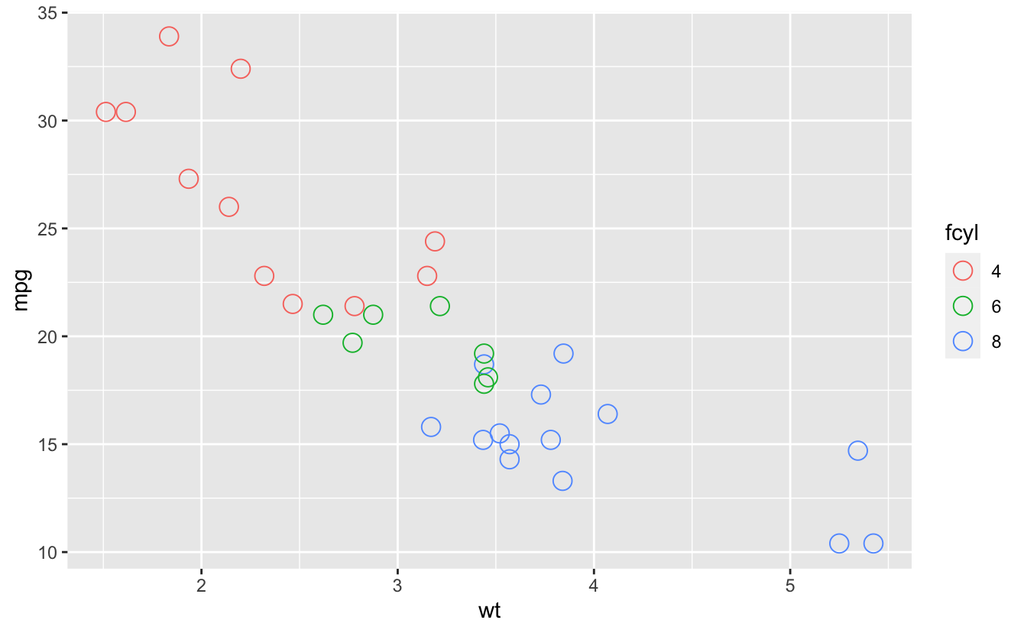

```r
##

ggplot(mtcars, aes(wt, mpg, color = fcyl)) +
  # Set the shape and size of the points
  geom_point(shape = 1, size = 4)
```

## All about aesthetics: color vs. fill

1. Change the aesthetics so that fcyl maps to fill rather than color.
2. In geom_point() change the shape argument to 21 and add an alpha argument set to 0.6.
3. In the ggplot() aesthetics, map fam to color.

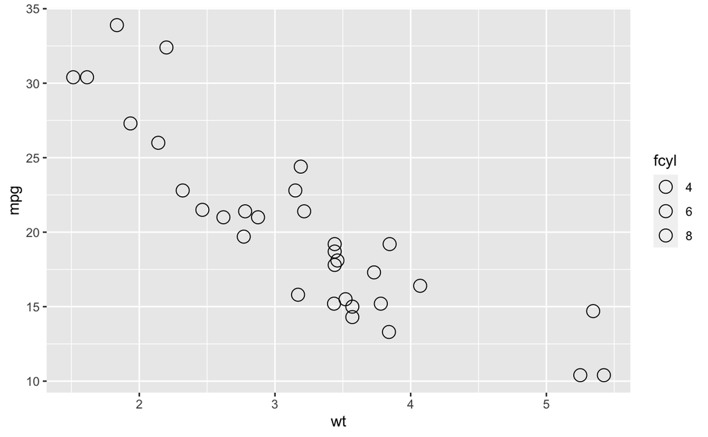

```r
# Map fcyl to fill
ggplot(mtcars, aes(wt, mpg, fill = fcyl)) +
  geom_point(shape = 1, size = 4)
```

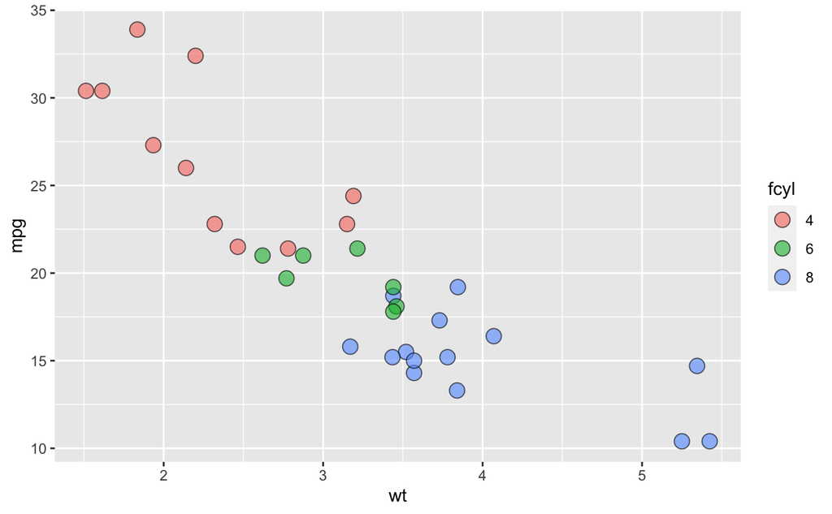

```r
ggplot(mtcars, aes(wt, mpg, fill = fcyl)) +
  # Change point shape; set alpha
  geom_point(alpha = 0.6, shape = 21, size = 4)
```

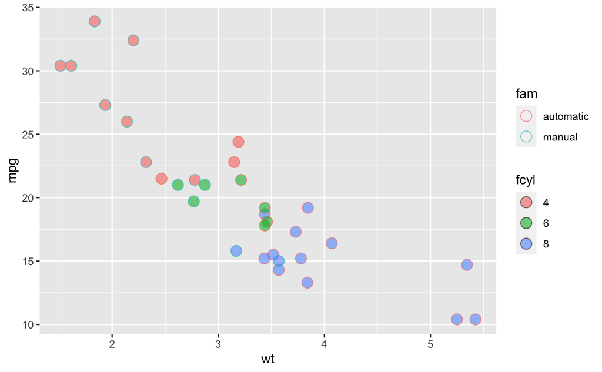

```r
###Map color to fam
ggplot(mtcars, aes(wt, mpg, color = fam,
                   fill = fcyl)) +
  geom_point(alpha = 0.6, shape = 21, size = 4)
```

## All about aesthetics: comparing aesthetics

1. Using mtcars, create a plot base layer, plt_mpg_vs_wt. Map mpg onto y and wt onto x.
- Add a point layer, mapping the categorical no. of cylinders, fcyl, onto size.
2. Change the mapping. This time fcyl should be mapped onto alpha.
3. Change the mapping again. This time fycl should be mapped onto shape.
4. Swap the geom layer: change points to text.
- Change the mapping again. This time fycl should be mapped onto label.

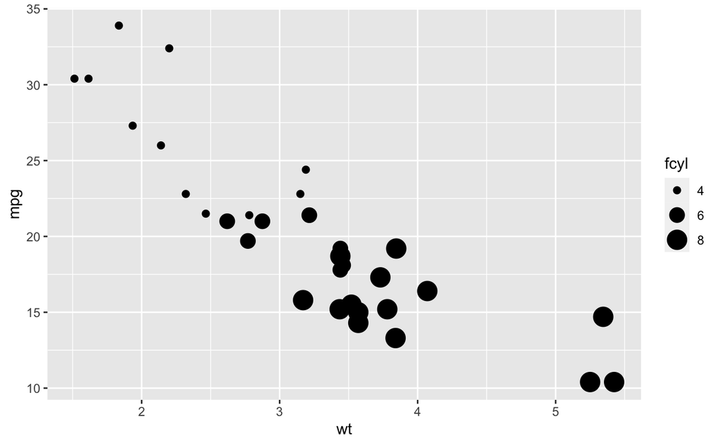

```r
# Establish the base layer
plt_mpg_vs_wt <- ggplot(mtcars, aes(x = wt, y = mpg))

# Map fcyl to size
plt_mpg_vs_wt +
  geom_point(aes(size = fcyl))
```

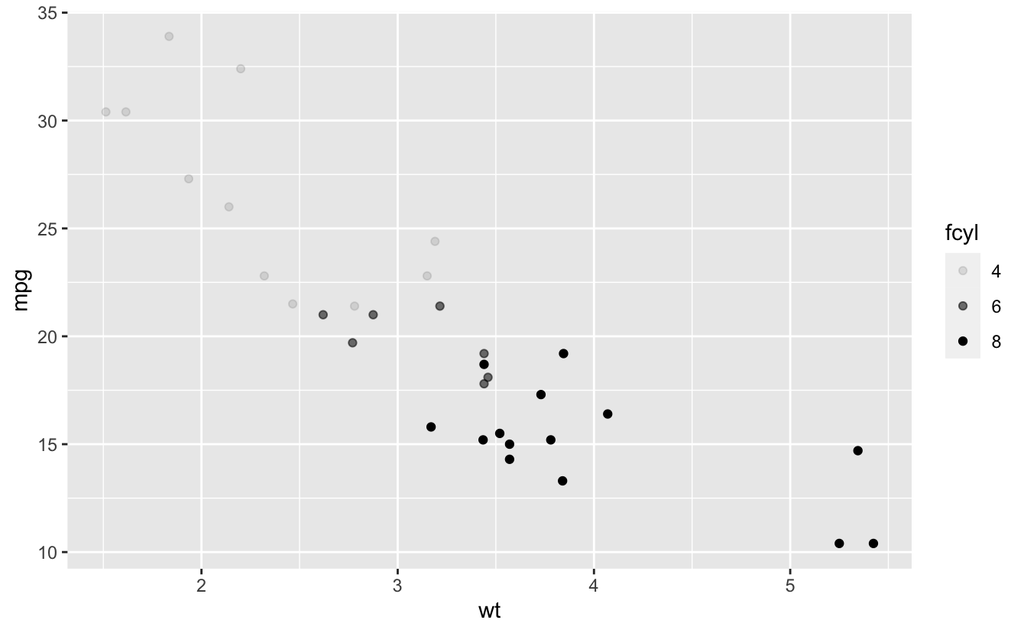

```r
# Map fcyl to alpha, not size
plt_mpg_vs_wt +
  geom_point(aes(alpha = fcyl))
```

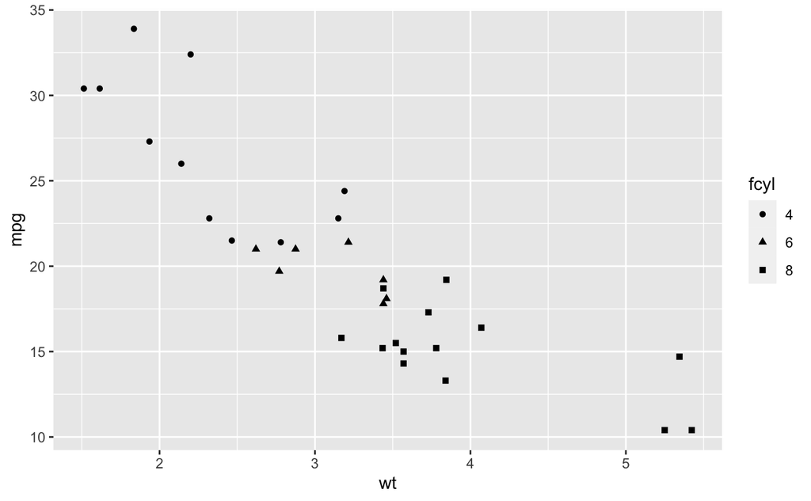

```r
# Map fcyl to shape, not alpha
plt_mpg_vs_wt +
  geom_point(aes(shape = fcyl))
```

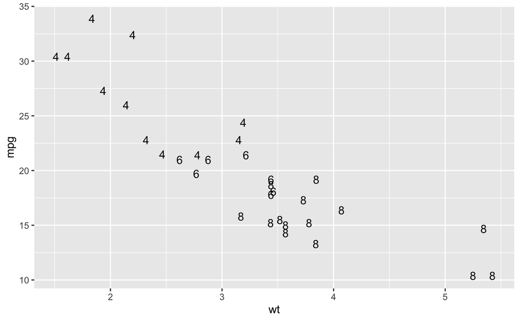

```r
# Use text layer and map fcyl to label
plt_mpg_vs_wt +
  geom_text(aes(label = fcyl))
```

## All about attributes: color, shape, size and alpha

1. Set the point color to my_blue and the alpha to 0.6.
2. Change the color mapping to a fill mapping. That is, fcyl should be mapped onto fill.
- Set the color of the points to my_blue, point size to 10 and the point shape to 1.

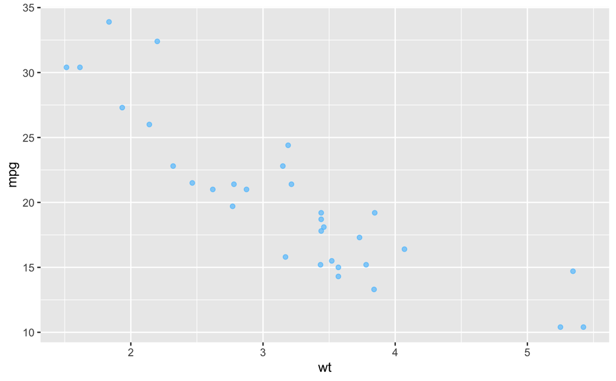

```r
# A hexadecimal color
my_blue <- "#4ABEFF"

ggplot(mtcars, aes(wt, mpg)) +
  # Set the point color and alpha
  geom_point(alpha = 0.6, color = my_blue)
```

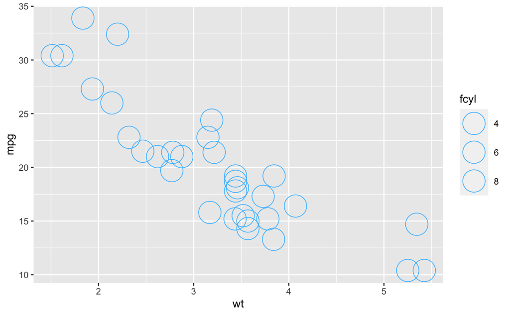

```r
# Change the color mapping to a fill mapping
ggplot(mtcars, aes(wt, mpg, fill = fcyl)) +
  # Set point size and shape
  geom_point(color = my_blue, size = 10, shape = 1)
```

## All about attributes: conflicts with aesthetics

1. Add a point layer, setting alpha, the transparency, to 0.5.
2. Add a text layer, setting the label to the rownames of the dataset mtcars, and the color to “red”.
3. Add a point layer, setting the shape to 24 and the color to “yellow”.

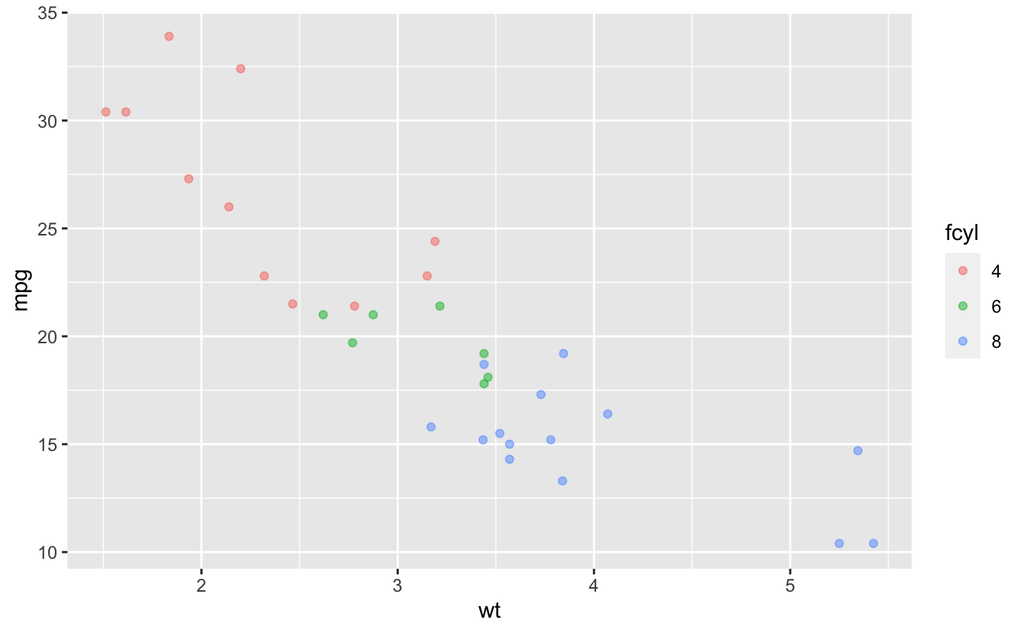

```r
#
ggplot(mtcars, aes(wt, mpg, color = fcyl)) +
  # Add point layer with alpha 0.5
  geom_point(alpha = 0.5)
```

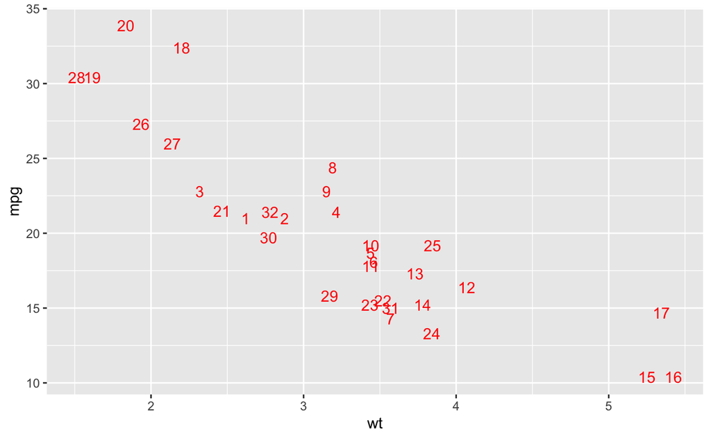

```r
ggplot(mtcars, aes(wt, mpg, color = fcyl)) +
  # Add text layer with label rownames(mtcars) and color red
  geom_text(label = row.names(mtcars), color = "red")
```

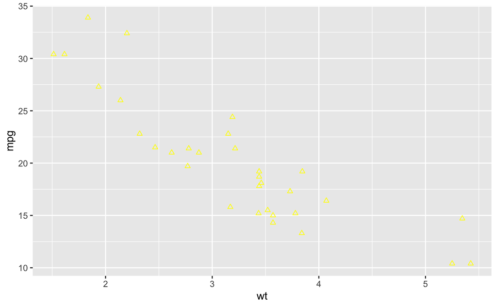

```r
ggplot(mtcars, aes(wt, mpg, color = fcyl)) +
  # Add points layer with shape 24 and color yellow
  geom_point(color = "yellow", shape = 24)
```

## Going all out

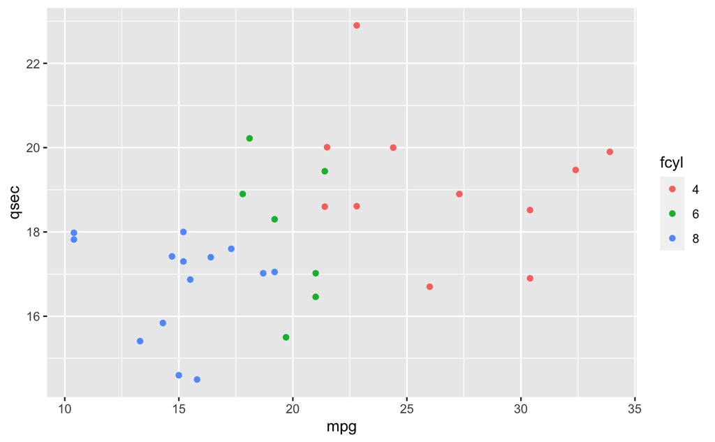

```r
# 3 aesthetics: qsec vs. mpg, colored by fcyl
ggplot(mtcars, aes(x = mpg, y= qsec, color = fcyl)) +
  geom_point()
```

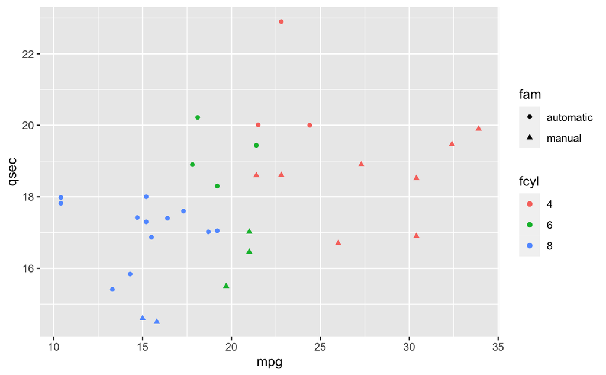

```r
# 4 aesthetics: add a mapping of shape to fam
ggplot(mtcars, aes(mpg, qsec, color = fcyl, shape = fam)) + geom_point()
```

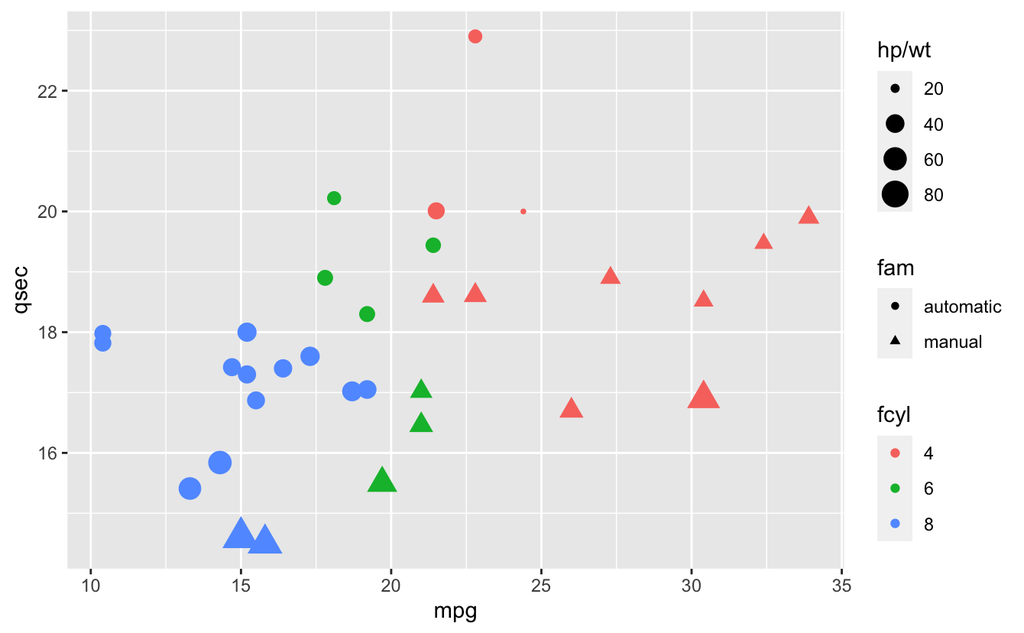

```r
# 5 aesthetics: add a mapping of size to hp / wt
ggplot(mtcars, aes(mpg, qsec, color = fcyl, shape = fam,
                   size = hp / wt)) + geom_point()
```